# gganimate package in R

Kevins_Kacha

2/9/2022

I was interested in sharing the package gganimate in R.

This helps to give the trend based on certain criterion like years.

In this lesson we will use the gapminder dataset. The data has conviniently been packaged in R, a subset of original dataset on(http://gapminder.org)\ For each of the 142 countries, the package provides values for life expectancy, GDP per capita and population every 5 years from 1952 to 2007

We first install the package if you havent installed. If you have installed it ,now call the package using the library() loading the gapminder dataset.

```r
##install.package(gapminder) if you haven't installed it.
library(gapminder)
```

Since we want to plot at some point using the ggaminate package, we need to install it so that we use it. The packages that comes in handy are tidyverse(ggplot2) for plotting, gganimate for the animation of the plot and gisfki for rendering the animation

```r
library(gapminder)
library(ggplot2)
library(gganimate)
library(gifski)
```

we need theme for the visualization.

```r
theme_set(theme_bw())## helps in visualization
head(gapminder) # helps to view the gapminder dataset
```

```
## # A tibble: 6 x 6
##   country     continent  year lifeExp      pop gdpPercap
##   <fct>       <fct>     <int>   <dbl>    <int>     <dbl>
## 1 Afghanistan Asia       1952    28.8  8425333      779.
## 2 Afghanistan Asia       1957    30.3  9240934      821.
## 3 Afghanistan Asia       1962    32.0 10267083      853.
## 4 Afghanistan Asia       1967    34.0 11537966      836.
## 5 Afghanistan Asia       1972    36.1 13079460      740.
## 6 Afghanistan Asia       1977    38.4 14880372      786.
```

## plotting of the graph

Introduction to ggplot()

```r
## ?ggplot()
#this will open a webpage that will help you understand more about the package ggplot.
```

Here we just plot using the using the ggplot()

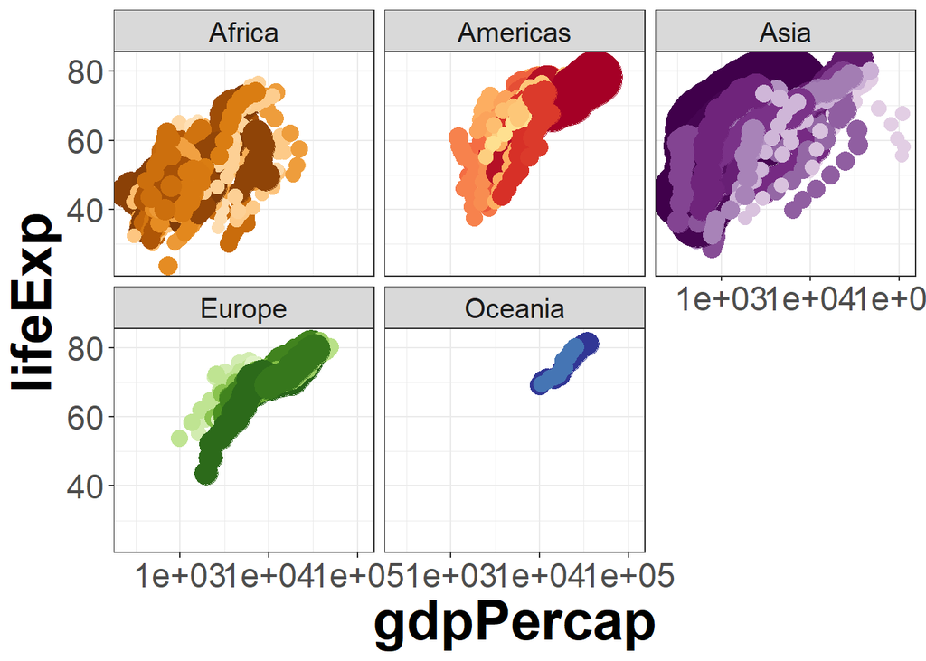

```r
gg<-ggplot(gapminder, aes(gdpPercap, lifeExp, size=pop, color=country))+
  geom_point(alpha=1.0)+
  scale_colour_manual(values = country_colors)+
  scale_size(range = c(3,25))+
  scale_x_log10()+
  facet_wrap(~continent)+
  theme(legend.position = "none")+
  theme(axis.text = element_text(size = 18),
        axis.title = element_text(size=30,face = "bold"),
        strip.text = element_text(size =15 ))
gg
```

labeling of the axis and specifying that the transition of the animation should be based on the year.

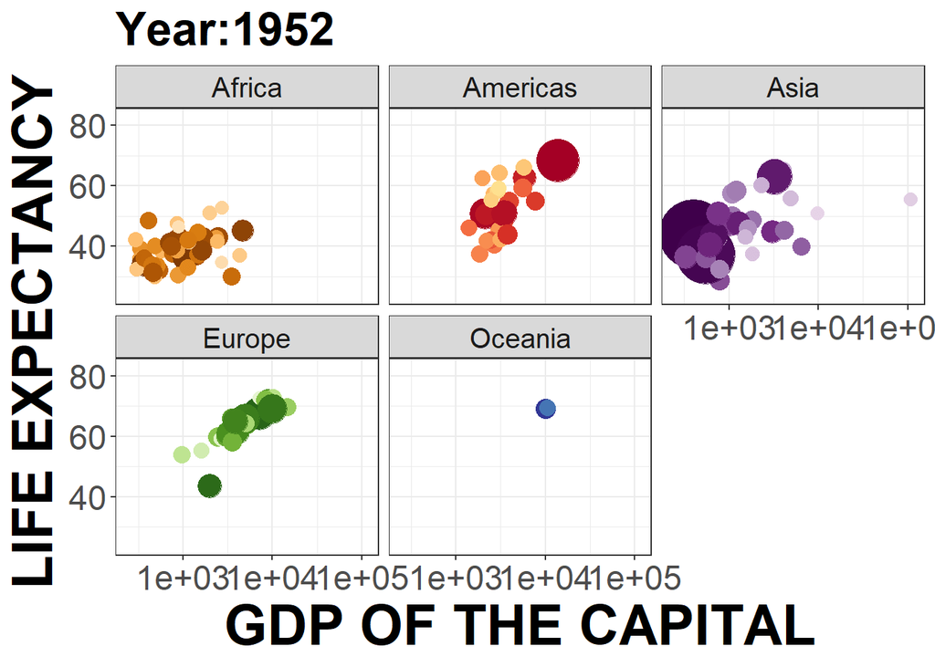

```r
gg2<-gg+labs(title = "Year:{frame_time}",x= "GDP OF THE CAPITAL", y="LIFE EXPECTANCY")+
  transition_time(year)+
  theme(plot.title = element_text(size = 25,face = "bold"))
gg2
```

If now you want to render the animation you use gifski package. number of frames (nframes=““) depends on the speed you wish the gif to go with. The lower the nframes(), the higer the speed and vice versa.

When the nframes() are low takes short time to render. The speed is very high

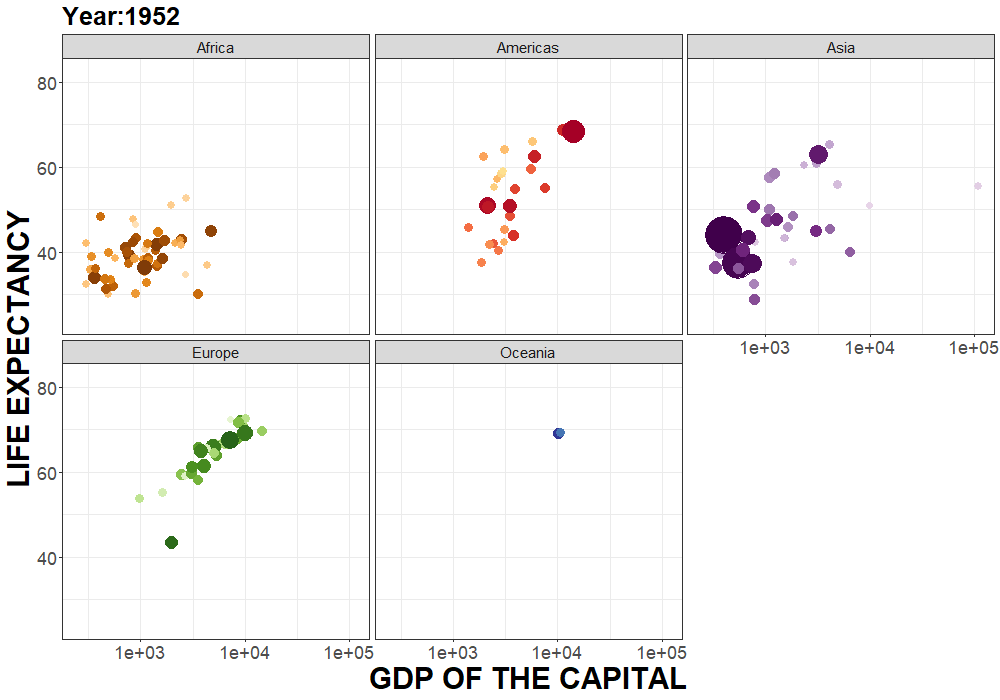

```r
animate(gg2,nframes = 10, renderer = gifski_renderer("gg2.gif"),height=700,width=1000)
```

When the nframes() are high takes sometime to render. The speed is very low

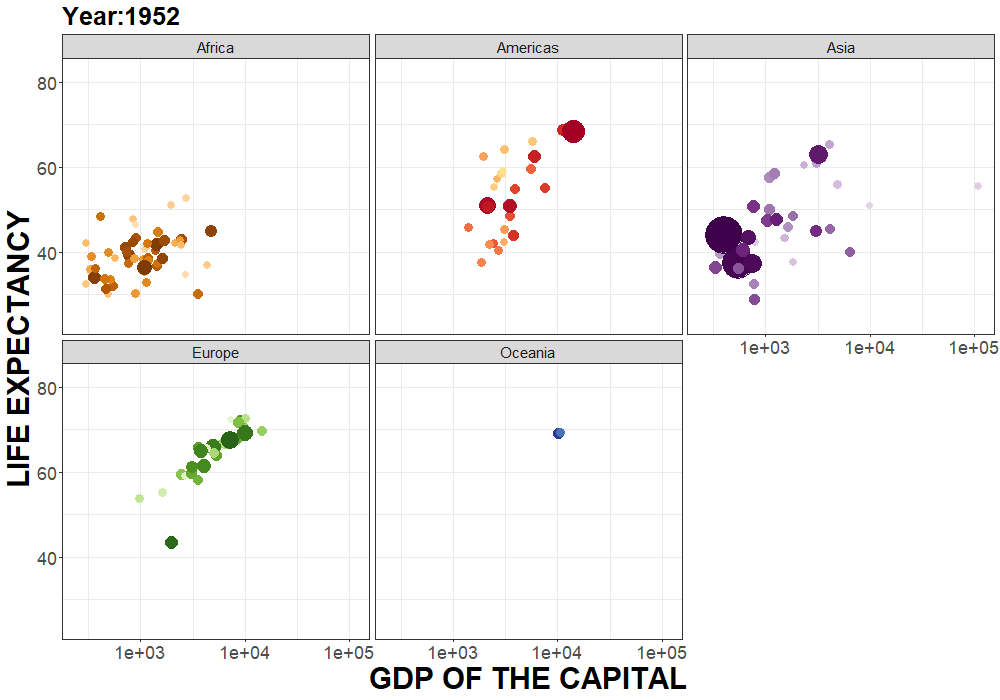

```r
animate(gg2,nframes = 50, renderer = gifski_renderer("gg2.gif"),height=700,width=1000)
```